# Notebook 4: Condições fiscais e mercado de trabalho

Disciplina: *Economia brasileira: análise de dados*

Author

[Patrick Andrade](https://www.github.com/patrick-andrade)

Published

May 27, 2026

Abstract

Dívida pública, resultado primário, gasto público e desemprego - Brasil x Colômbia

## 1 Objetivo

Este relatório transforma os principais resultados do script `04-notebook4-conteudo.R` em uma página HTML legível e reprodutível.

Ideia central: dividir a análise em duas partes

- script `.R`: faz a análise completa, baixa os dados, trata a base e salva os resultados;
- arquivo `.qmd`: organiza os principais gráficos, tabelas e interpretações para leitura.

**NoteLeitura do relatório**

Um notebook Quarto não precisa substituir o script.  
Em trabalhos aplicados, costuma ser melhor deixar o script como “motor” da análise e usar o `.qmd` como produto de comunicação.

## 2 Fonte e recorte

**O exercício compara Brasil e Colômbia entre 2000 e 2025.**

- A análise combina indicadores fiscais, mercado de trabalho e decomposições macroeconômicas.
- Resultados: foram gerados previamente pelo script principal e salvos nas pastas `outputs/figs/` e `outputs/tables/`.

## 3 Dívida pública bruta

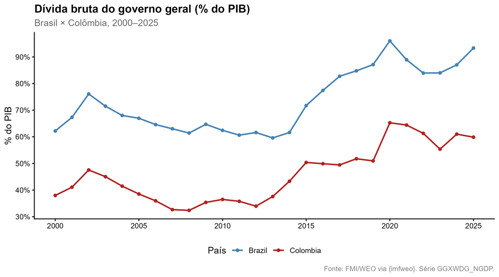

Figure 1: Dívida pública bruta - Brasil x Colômbia

**Comparação da dívida bruta**:

- Permite observar não apenas o nível da dívida, mas também a direção da trajetória

**Para a discussão econômica**:

- Pergunta principal não é só “quem tem dívida maior?”, mas “em quais períodos a dívida muda de patamar e por que?”

**TipOrientação de leitura**

- Identifique visualmente os pontos de inflexão na trajetória brasileira e outro na trajetória colombiana.
- Depois, conecte essas mudanças a períodos macroeconômicos concretos: recessão, pandemia, juros reais, resultado primário e crescimento.

## 4 Resultado primário

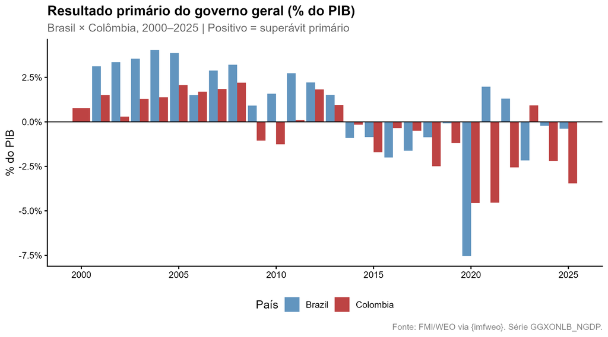

Figure 2: Resultado primário - Brasil x Colômbia

**Resultado primário**: - Uma das principais medidas para discutir política fiscal. - Mostra a diferença entre receitas e despesas antes do pagamento de juros.

**Em termos simples**:  
- superávit primário ajuda a estabilizar ou reduzir a dívida; - déficit primário pressiona a dívida para cima; - o efeito final depende também dos juros reais (`r`)e do crescimento (`g`).

## 5 Mercado de trabalho

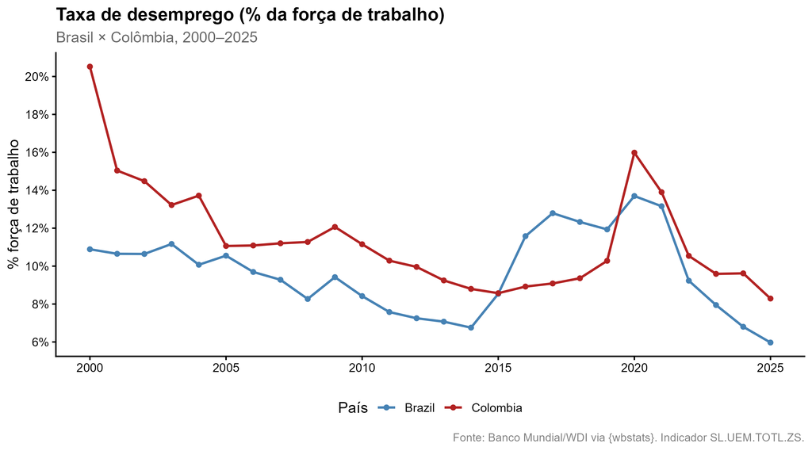

Figure 3: Taxa de desemprego - Brasil x Colômbia

**Comparação do desemprego**:

- Países com instituições macroeconômicas parcialmente parecidas podem ter mercados de trabalho muito diferentes.
- Análise gráfica:
  - Abre espaço para discutir informalidade, estrutura produtiva, legislação trabalhista, composição setorial e choques agregados.

## 6 Decomposição da dinâmica da dívida

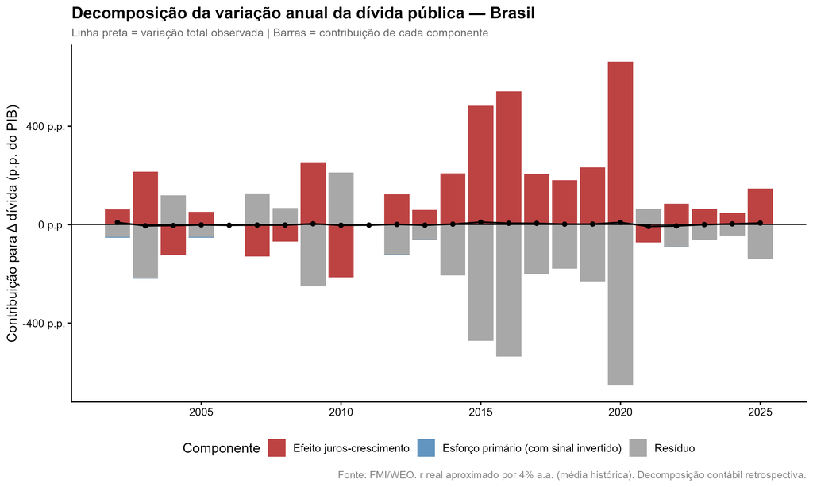

Figure 4: Decomposição da variação da dívida brasileira

**Esta é a parte conceitual mais importante do notebook**.

A variação da dívida pode ser lida como uma combinação entre:

- efeito snowball: relação entre juros reais, crescimento e estoque de dívida;
- resultado primário: esforço fiscal antes dos juros;
- resíduos e demais fatores contábeis.

**NoteOrientação de leitura**

Uma forma útil de ler este gráfico é partir da pergunta:

*“A dívida sobe porque o governo teve déficit primário ou porque a combinação juros-crescimento foi desfavorável?”*

Essa pergunta desloca a análise de uma leitura moral da dívida para uma leitura contábil e macroeconômica.

## 7 PIB pela ótica da demanda

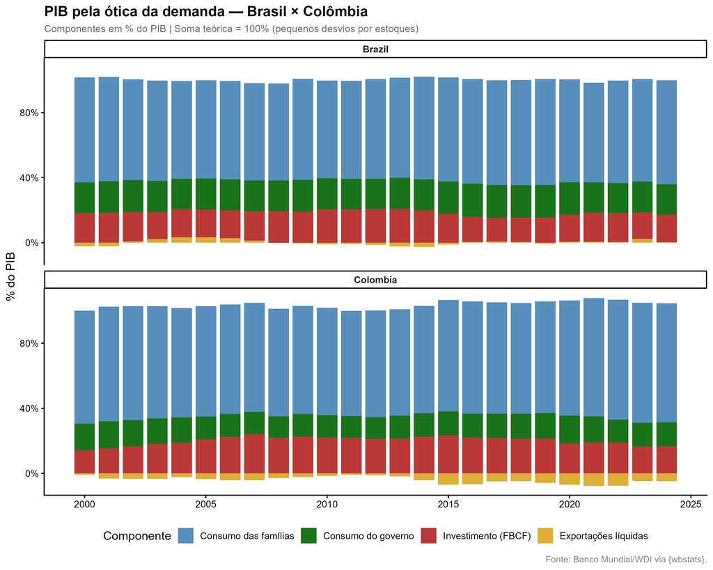

## 8 Tabela por subperíodos

Resumo por subperíodos

Brasil x Colômbia

| pais | subperiodo | divida_media | primario_medio | gasto_medio | desemprego_medio | crescimento_medio | n_anos |
| --- | --- | --- | --- | --- | --- | --- | --- |
| Brazil | 2000-2004 | 69.03241 | 3.5224720 | NA | 10.683800 | 3.1464242 | 5 |
| Brazil | 2005-2009 | 64.14273 | 2.4753970 | NA | 9.442000 | 3.6404760 | 5 |
| Brazil | 2010-2014 | 61.17860 | 1.4314412 | 28.46594 | 7.415000 | 3.3865258 | 5 |
| Brazil | 2015-2019 | 80.75847 | -1.0869136 | 32.61657 | 11.435000 | -0.4988688 | 5 |
| Brazil | 2020-2025 | 88.87292 | -1.1708887 | 32.12065 | 9.467333 | 2.2415195 | 6 |
| Colombia | 2000-2004 | 42.63002 | 1.0505136 | 22.27771 | 15.395800 | 3.2716112 | 5 |
| Colombia | 2005-2009 | 34.98683 | 1.3497020 | 24.64924 | 11.338600 | 4.4650454 | 5 |
| Colombia | 2010-2014 | 37.43160 | 0.2890642 | 27.62198 | 9.889000 | 4.9976674 | 5 |
| Colombia | 2015-2019 | 50.49201 | -1.2477790 | 28.84559 | 9.244000 | 2.4307384 | 5 |
| Colombia | 2020-2025 | 61.20518 | -2.7315728 | 34.48620 | 11.320333 | 2.6534337 | 6 |

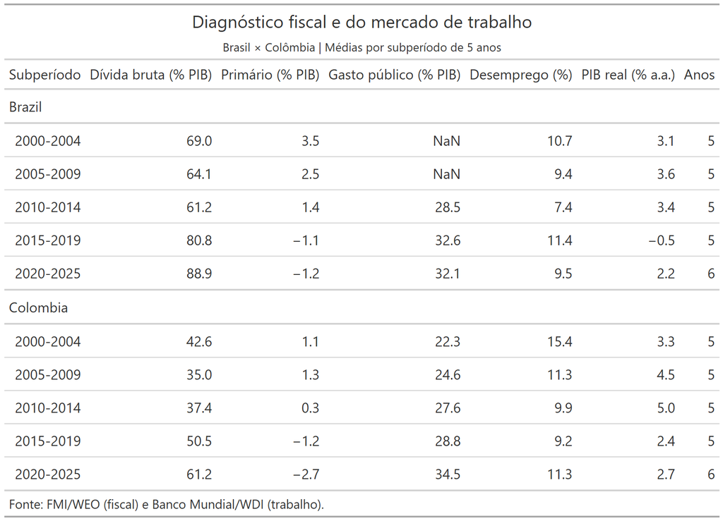

Figure 6: Tabela exportada como imagem pelo script principal

## 9 Síntese interpretativa

Uma boa interpretação deve citar números, anos e mecanismos.

Evite frases genéricas como “a economia piorou” ou “a dívida aumentou”.

Prefira frases do tipo:

- “Entre 2015 e 2025, a dívida bruta brasileira aumentou em X pontos percentuais do PIB, enquanto a colombiana aumentou Y.”
- “No subperíodo 2005-2009, o resultado primário brasileiro foi mais favorável, o que ajudou a conter a trajetória da dívida.”
- “Em 2020, a pandemia aparece como choque fiscal e macroeconômico atípico, combinando queda de atividade e deterioração fiscal.”

**ImportantTarefa final**

Escreva de 3 a 5 frases interpretativas usando pelo menos dois gráficos e a tabela de subperíodos.  
Cada frase deve conter uma evidência numérica ou uma referência temporal clara.